# Case-Control Point Data Homework (Local Rates and Nearest Neighbors)

Instructions: Answer the following questions and write your answers in a word processor. Mathematical symbols should be written using the equation editor. Appropriate graphics should be included. The document may also be created in LaTeX, though this is NOT encouraged.

Packages and data pulls

```r
library(smacpod)
library(spatstat)
library(spatstat.random)
data(urkiola)
data(paracou)
urkiola
```

```
Marked planar point pattern: 1245 points
Multitype, with levels = birch, oak
window: polygonal boundary
enclosing rectangle: [0.05, 219.95] x [0.05, 149.95] metres
```

```r
paracou
```

```
Marked planar point pattern: 884 points
Multitype, with levels = adult, juvenile
window: rectangle = [0, 400.8568] x [0, 524.4037] metres
```

# Problem 1

The `urkiola` data set in the **spatstat package** contains locations of birch (Betula celtiberica) and oak (Quercus robur) trees in a secondary wood in Urkiola Natural Park (Basque country, northern Spain). They are part of a more extensive dataset collected and analysed by Laskurain (2008). The coordinates of the trees are given in meters. Let the “oak” trees be the cases and “birch” trees be the controls.

## a.

Perform a test to determine whether the most unusual window of case/control event locations in the study area can be considered a cluster using the spatial scan statistic under the random labeling hypothesis. Use $n_{sim}=199$ randomly labeled data sets and $\alpha=0.10$. Make sure to clearly describe your null and alternative hypotheses. Make your conclusion in the context of the problem.

Before completing the test, our null and alternative hypothesis is the following 𝐻0: There are no cluster of oak tress in the study area. 𝐻𝑎: There is at least one cluster of oak trees in the study area. or even more specifically with our exact test

𝐻0: There are no windows where the most likely cluster is more unusual than what is expected under the random labeling hypothesis. 𝐻𝑎: There is at least one window where the most likely cluster is more unusual than what is expected under the random labeling hypothesis.

```r
scan = spscan.test(urkiola, nsim = 199, case = "oak" , alpha = .10)
```

```
oak has been selected as the case group
```

Scan summary in a seperate cell

```r
summary(scan)
```

```
  centroid_x centroid_y radius events cases    ex  rr stat     p
1      144.7       69.6   77.4    875   313 252.3 2.9 38.3 0.005
```

As we can see our p value is .005 thus indicating that we reject our null hypothesis. In this case we notice that the labeling of oak trees is not consistent with the random labeling hypothesis, or that given we randomly label trees as oak or birch we notice that this is not similar to what we have. This is used by a window that moves and scans each area noticing if there is clustering there.

## b.

Using your analysis from the previous problem, create a plot of the case/control event locations, the associated study area boundary, and a legend indicating the cases/controls. Add the window identifying the most unusual window of case/control event locations (according to the spatial scan statistic) and any potential secondary clusters. Comment on the results.

Now lets go ahead and plot it.

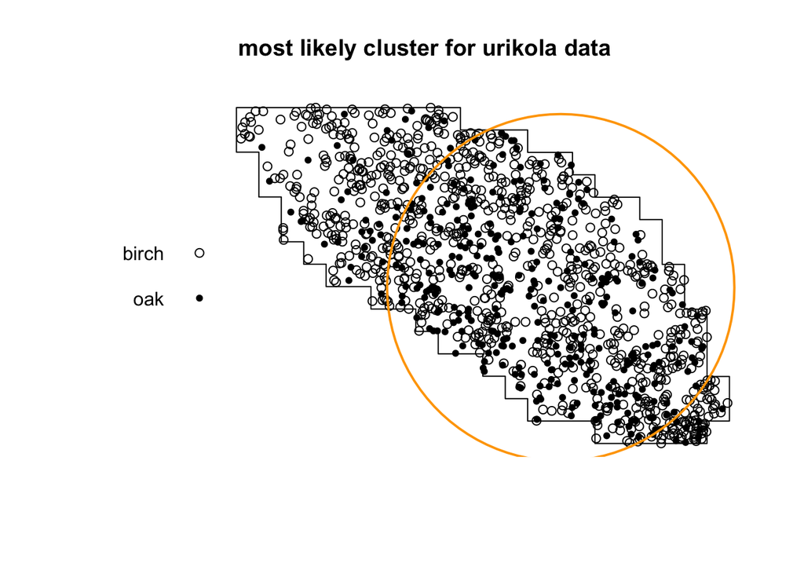

```r
plot(scan, chars = c(1, 20),
     main = "most likely cluster for urikola data",
     border = "orange")
```

```r
# extract most likely and other significant clusters
clusters(scan)
```

[output not shown]

[output cut: 45 more lines]

```r
cl <- parallel::makeCluster(getOption("cl.cores", 2))

# if there were more than 1 cluster ....
scan2 = spscan.test(urkiola, nsim = 499, case = "oak",
                    alpha = 0.10, cl = cl)
```

```
oak has been selected as the case group
```

```r
summary(scan2)
```

```
  centroid_x centroid_y radius events cases    ex  rr stat     p
1      144.7       69.6   77.4    875   313 252.3 2.9 38.3 0.002
```

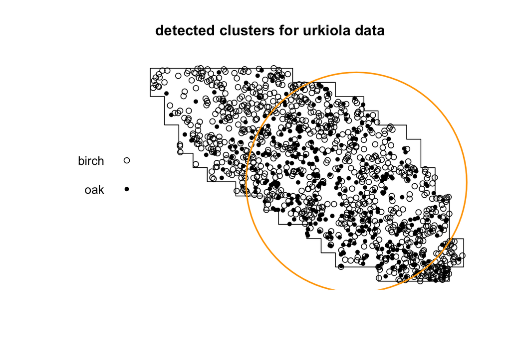

```r
plot(scan2, chars = c(1, 20),
     main = "detected clusters for urkiola data",
     border = c("orange"))
```

```r
clusters(scan2)
```

[output not shown]

[output cut: 45 more lines]

To me it seems like the “cluster” shown is extremely big on the map thus I don’t know how helpful it is to really pinpoint. However, from past homework this is where we saw some sort of clustering going on so, this is probably what this method could be pinpointing.

## c.

Perform a test for clustering using the q nearest neighbors method. Use $q=3,5,\ldots,19$ and $n_{sim}=499$ randomly labeled data sets. For which $q$ are there more cases than we would expect under random labeling in the $q$ locations nearest each case? At what scale does this clustering appear to occur (use the contrasts)?

Now we need to developed our test statistic.

```r
# q nearest neighbor test
# use position in levels(grave$marks) to select case group
qnn.test(urkiola,
         q = seq(3, 19, by = 2),
         nsim = 499,
         case = "oak")
```

```
oak has been selected as the case group
```

```
Q nearest neighbors test

case label:  oak
control label:  birch

Summary of observed test statistics

  q   Tq pvalue
  3  377  0.004
  5  637  0.002
  7  887  0.002
  9 1125  0.002
 11 1374  0.002
 13 1607  0.002
 15 1855  0.002
 17 2084  0.002
 19 2285  0.002

Summary of observed contrasts between test statistics

  contrast Tcontrast pvalue
   T5 - T3       260  0.002
   T7 - T3       510  0.002
   T9 - T3       748  0.002
  T11 - T3       997  0.002
  T13 - T3      1230  0.002
  T15 - T3      1478  0.002
  T17 - T3      1707  0.002
  T19 - T3      1908  0.002
   T7 - T5       250  0.002
   T9 - T5       488  0.002
  T11 - T5       737  0.002
  T13 - T5       970  0.002
  T15 - T5      1218  0.002
  T17 - T5      1447  0.002
  T19 - T5      1648  0.002
   T9 - T7       238  0.014
  T11 - T7       487  0.002
  T13 - T7       720  0.002
  T15 - T7       968  0.002
  T17 - T7      1197  0.002
  T19 - T7      1398  0.002
  T11 - T9       249  0.008
  T13 - T9       482  0.002
  T15 - T9       730  0.002
  T17 - T9       959  0.002
  T19 - T9      1160  0.002
 T13 - T11       233  0.032
 T15 - T11       481  0.004
 T17 - T11       710  0.002
 T19 - T11       911  0.006
 T15 - T13       248  0.002
 T17 - T13       477  0.006
 T19 - T13       678  0.014
 T17 - T15       229  0.050
 T19 - T15       430  0.190
 T19 - T17       201  0.646
```

# Problem 2

Answer the same questions as Problem 1 for the `paracou` data set in the **spatstat** package. Let the `juveniles` be the controls and `adults` be the cases.

## a.

Perform a test to determine whether the most unusual window of case/control event locations in the study area can be considered a cluster using the spatial scan statistic under the random labeling hypothesis. Use $n_{sim}=199$ randomly labeled data sets and $\alpha=0.10$. Make sure to clearly describe your null and alternative hypotheses. Make your conclusion in the context of the problem.

```r
scan3 = spscan.test(paracou, nsim = 199, case = "adult" , alpha = .10)
```

```
adult has been selected as the case group
```

```r
summary(scan3)
```

```
  centroid_x centroid_y radius events cases  ex   rr stat    p
1   46.82281          2   30.5      6     4 0.3 13.9  8.3 0.17
```